# Лабораторная работа №8

Дисциплина: Сетевые технологии

Бахи сиди али темассини

1032234211@pfur.ru

Российский университет дружбы народов

2026-03-05

# Цель работы

## Цель работы

- Изучение принципов маршрутизации
- Работа с IPv4 и IPv6
- Настройка сетевого оборудования

# Настройка динамической маршрутизации в сетях IPv4 и IPv6

## Развёртывание моделируемой сети в GNS3

- Запуск GNS3 VM и GNS3
- Создание нового проекта
- Размещение маршрутизаторов FRR, коммутаторов и VPCS
- Формирование кольцевой топологии из 4 маршрутизаторов
- Подключение:
  - PC1 → sw-01 → gw-01
  - PC2 → sw-02 → gw-03
- Переименование устройств:
  - `msk-user-sw-0x`
  - `msk-user-gw-0x`
  - `PCx-bahi`
- Включение захвата трафика:
  - sw-01 ↔︎ gw-01
  - sw-02 ↔︎ gw-03

[figure not shown]

## Назначение IPv4-адресов оконечным устройствам

- Настройка IPv4-адресов на PC1 и PC2
- PC1:
  - IP: `10.0.10.10/24`
  - Gateway: `10.0.10.1`
- PC2:
  - IP: `10.0.11.10/24`
  - Gateway: `10.0.11.1`
- Сохранение конфигурации
- Проверка командой `show ip`

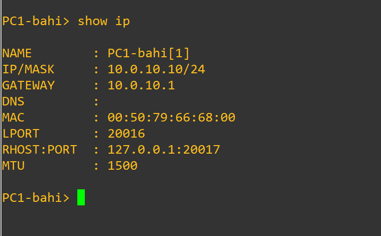

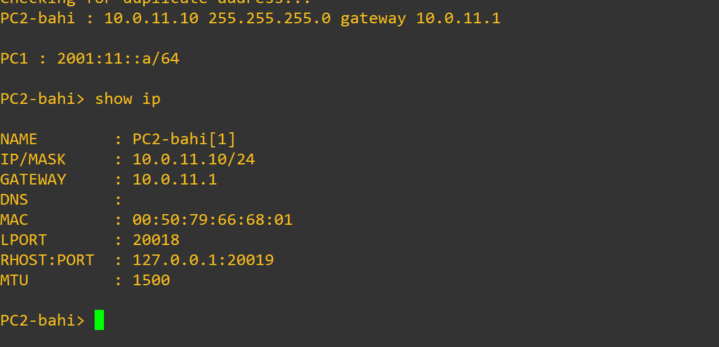

## Настройка IPv4-адресации на msk-user-gw-01

- Назначение IPv4-адресов:
  - eth0
  - eth1
  - eth2
- Активация интерфейсов (`no shutdown`)
- Сохранение конфигурации
- Проверка `show running-config`

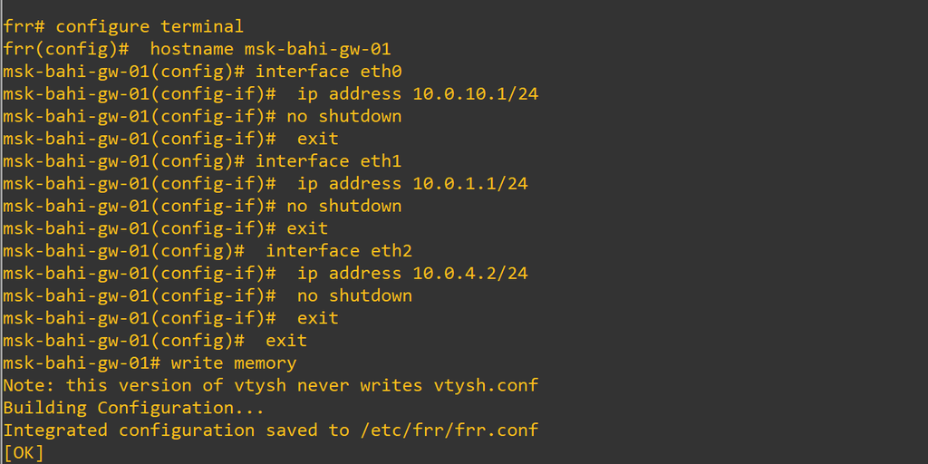

## Настройка IPv4-адресации на msk-user-gw-02

- Назначение IPv4-адресов:
  - eth0
  - eth1
- Активация интерфейсов
- Сохранение конфигурации
- Проверка текущих параметров

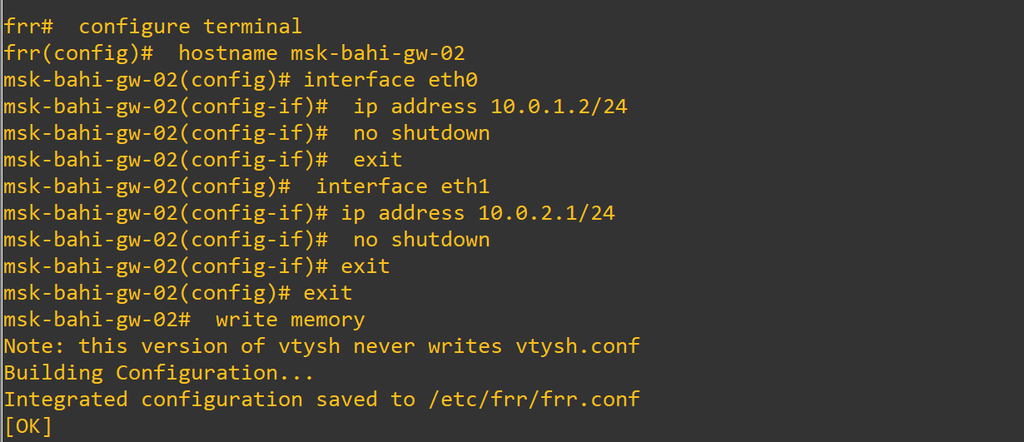

## Настройка IPv4-адресации на msk-user-gw-03

- Назначение IPv4-адресов:
  - eth0
  - eth1
  - eth2
- Подключение к локальной и транзитным сетям
- Активация интерфейсов
- Проверка `show running-config`

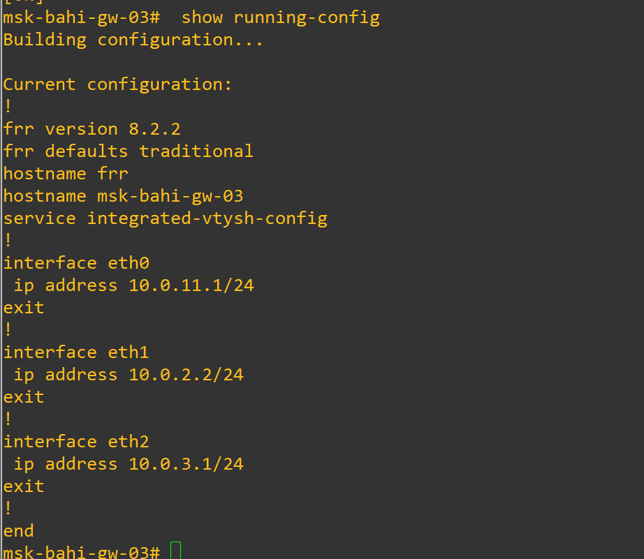

## Настройка IPv4-адресации на msk-user-gw-04

- Назначение IPv4-адресов:
  - eth0
  - eth1
- Активация интерфейсов
- Сохранение конфигурации
- Проверка корректности настроек

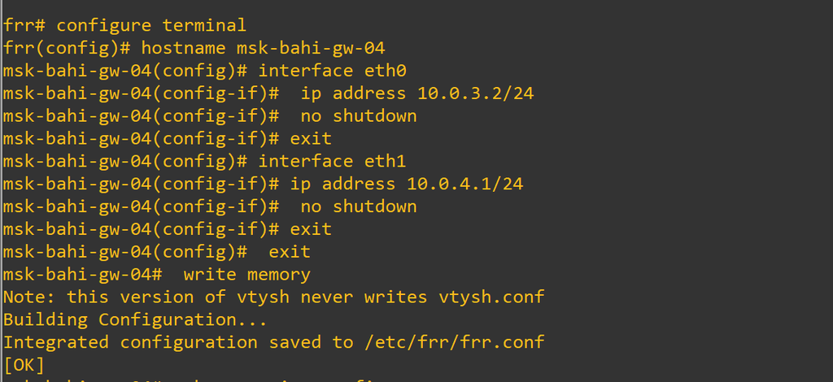

## Назначение IPv6-адресов оконечным устройствам

- Ручная настройка IPv6 через VPCS
- PC1:
  - IPv6: `2001:10::a/64`
  - Проверка `show ipv6`
- PC2:
  - IPv6: `2001:11::a/64`
  - Проверка `show ipv6`
- Подтверждение наличия global и link-local адресов

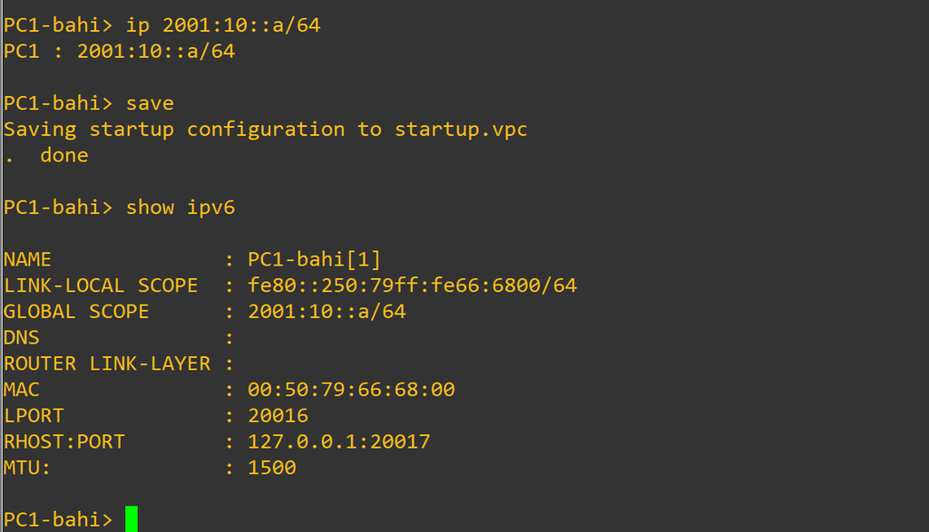

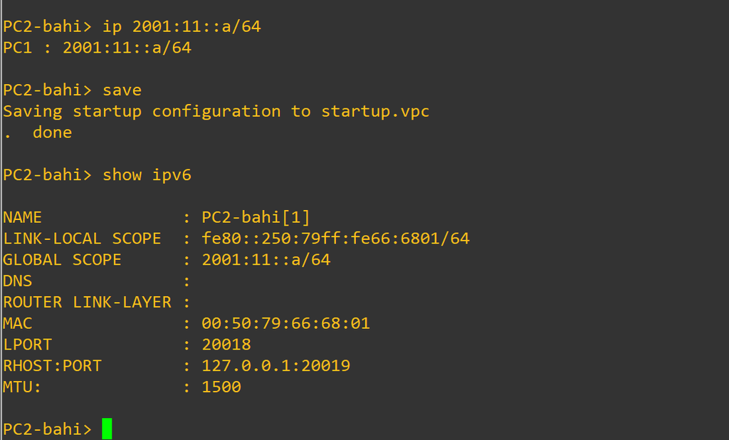

## Настройка IPv6-адресации на msk-user-gw-01

- Включение IPv6 forwarding
- Назначение IPv6-адресов:
  - eth0
  - eth1
  - eth2
- Включение Router Advertisement на eth0

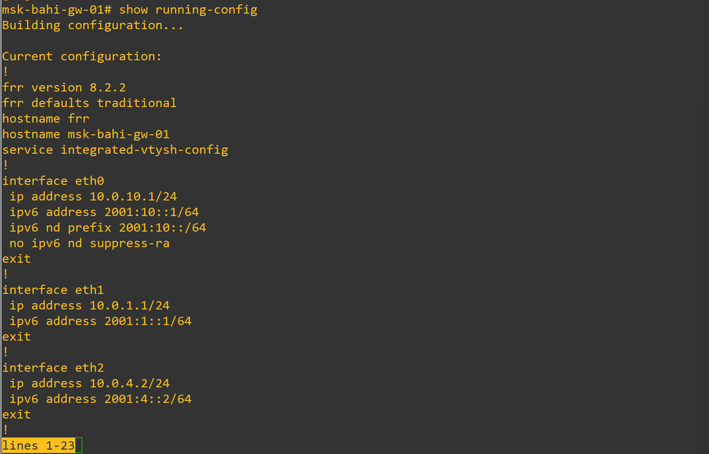

## Настройка IPv6-адресации на msk-user-gw-02

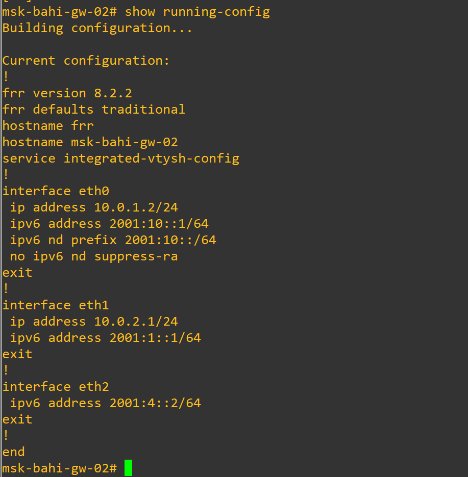

## Настройка IPv6-адресации на msk-user-gw-03

- Активация IPv6
- Назначение IPv6-адресов:
  - eth0
  - eth1
  - eth2
- Включение Router Advertisement на eth0
- Проверка конфигурации

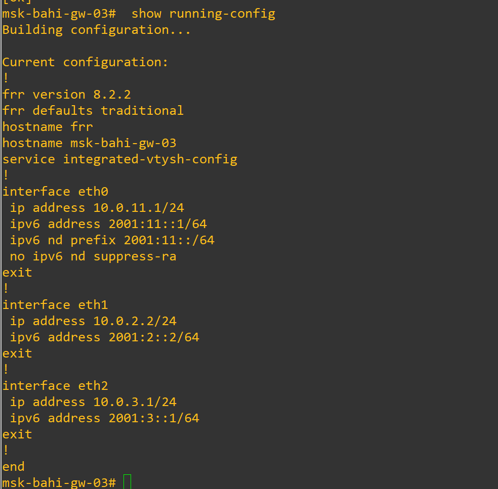

## Настройка IPv6-адресации на msk-user-gw-04

- Включение IPv6 forwarding
- Назначение IPv6-адресов:
  - eth0
  - eth1
- Активация интерфейсов
- Готовность к IPv6-маршрутизации

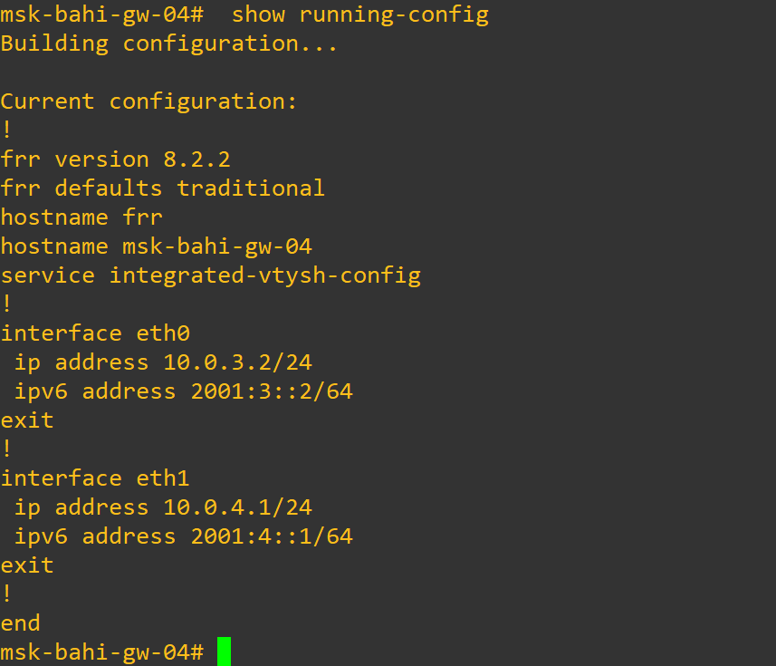

# Настройка динамической маршрутизации по протоколу RIP

## Настройка RIP на msk-user-gw-01

- Включение RIP версии 2
- Активация на интерфейсах:
  - eth0
  - eth1
  - eth2
- Объявление всех подключённых сетей
- Сохранение конфигурации

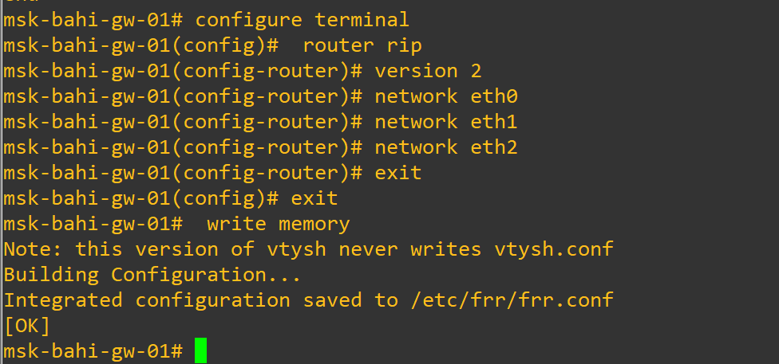

## Настройка RIP на msk-user-gw-02

- Включение RIPv2
- Активация на интерфейсах:
  - eth0
  - eth1
- Участие в обмене маршрутами

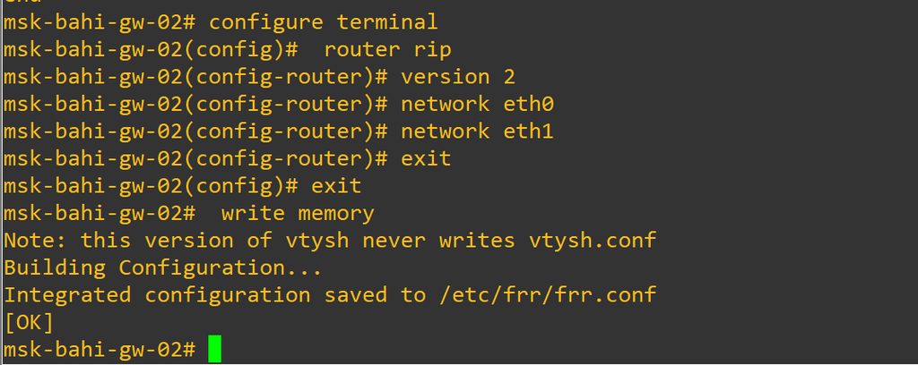

## Настройка RIP на msk-user-gw-03

- Включение RIPv2
- Активация на интерфейсах:
  - eth0
  - eth1
  - eth2
- Распространение маршрутной информации

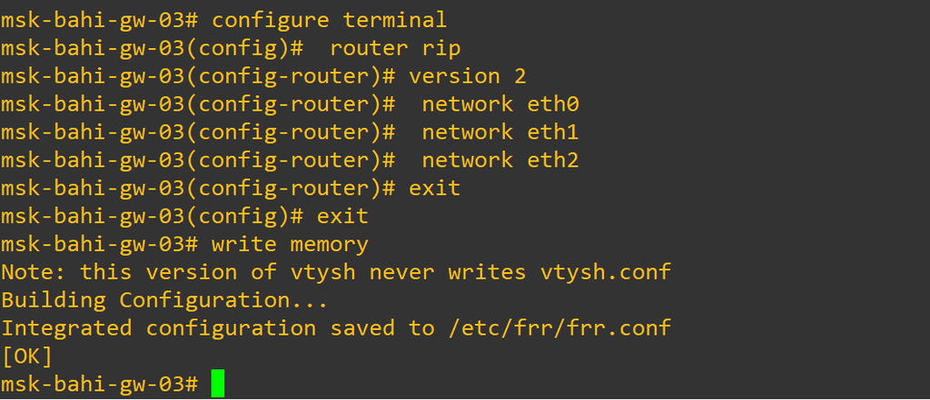

## Настройка RIP на msk-user-gw-04

- Включение RIPv2
- Активация на интерфейсах:
  - eth0
  - eth1
- Корректная работа RIP

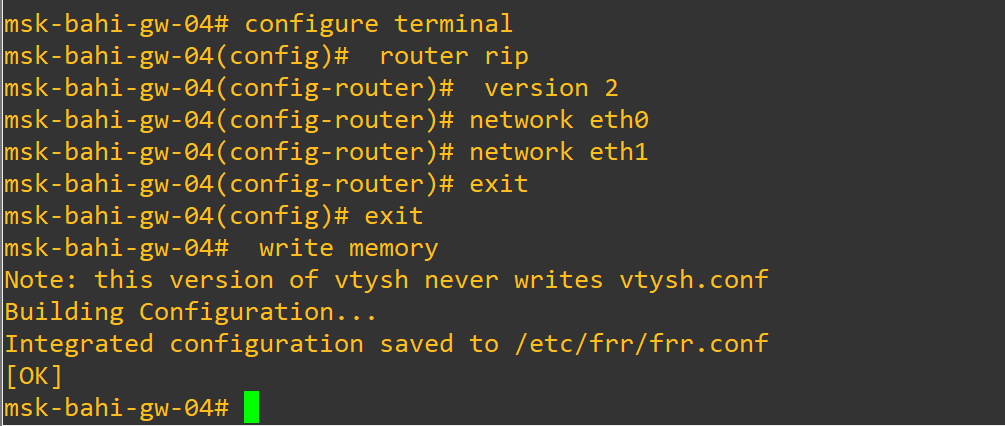

## Проверка корректности маршрутизации RIP

- Проверка команд:
  - `show ip route rip`
  - `show ip rip`
  - `show ip rip status`
- Получение удалённых маршрутов
- Метки `R` в таблице маршрутизации
- Период обновлений: 30 секунд

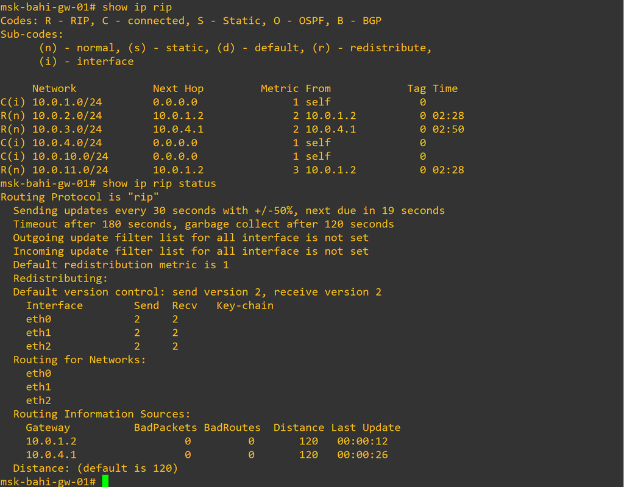

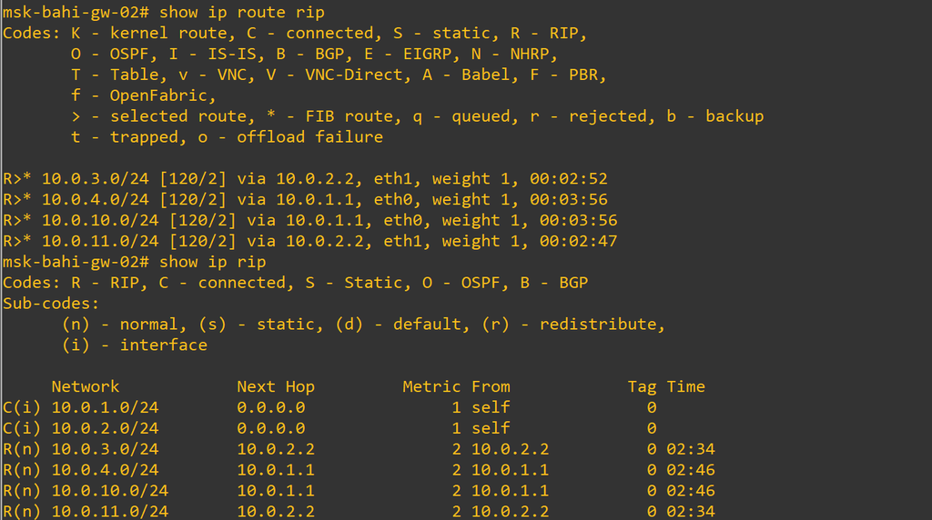

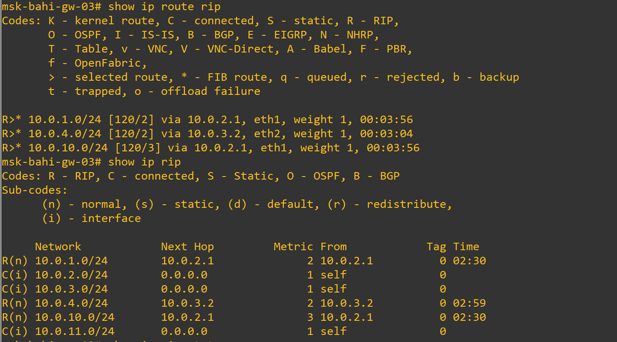

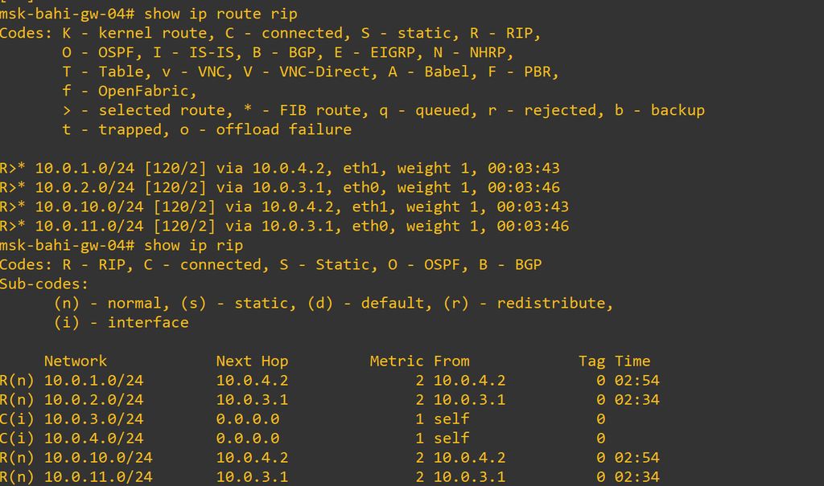

## Проверка связности PC1 → PC2 (нормальный режим)

- Ping `10.0.11.10`
- Успешные ICMP-ответы
- Traceroute показывает маршрут через несколько маршрутизаторов

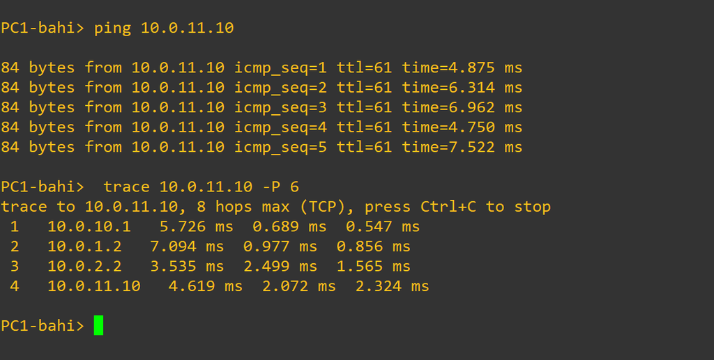

## Анализ метрик RIP в штатном режиме

- Выполнение `show ip rip`
- Метрики < 16
- Основной маршрут через msk-user-gw-02

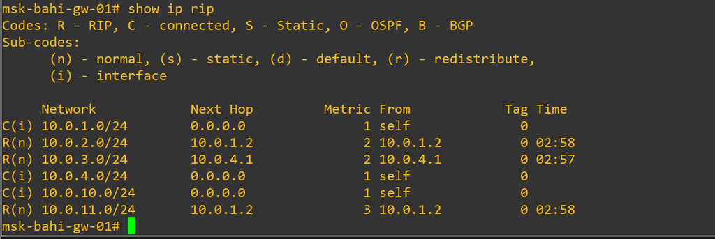

## Отказ интерфейса на msk-user-gw-02

- Отключение eth0 (`shutdown`)
- Маршруты получают метрику 16
- RIP помечает маршруты как недостижимые

## Потеря связности при отказе канала

- Ping PC1 → PC2 не проходит
- Traceroute:
  - `Destination host unreachable`
- Отсутствие активного маршрута

## Восстановление маршрута (RIP convergence)

- Получение альтернативных маршрутов
- Новый путь через msk-user-gw-04
- Успешный ping
- Время восстановления — десятки секунд

## Включение интерфейса msk-user-gw-02

- Команда `no shutdown`
- Возврат основного маршрута
- Метрики восстановлены

## Анализ перехваченного трафика RIP

- RIP-пакеты на `224.0.0.9`
- Объявление сетей и метрик
- Метрика 16 при отказе
- ICMP Echo Request / Reply
- Анализ TTL и IP-адресов

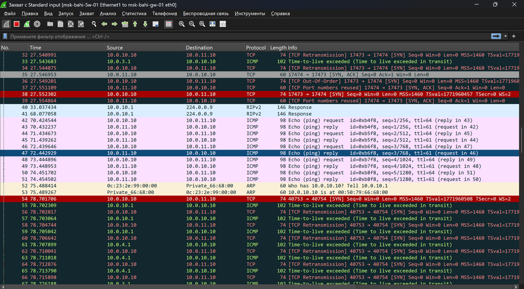

[figure not shown]

# Настройка динамической маршрутизации по протоколу OSPF

## Настройка OSPFv2 на msk-bahi-gw-01

- Активация протокола OSPFv2
- Добавление сетей:
  - 10.0.10.0/24
  - 10.0.1.0/24
  - 10.0.4.0/24
- Использование области 0.0.0.0
- Сохранение конфигурации

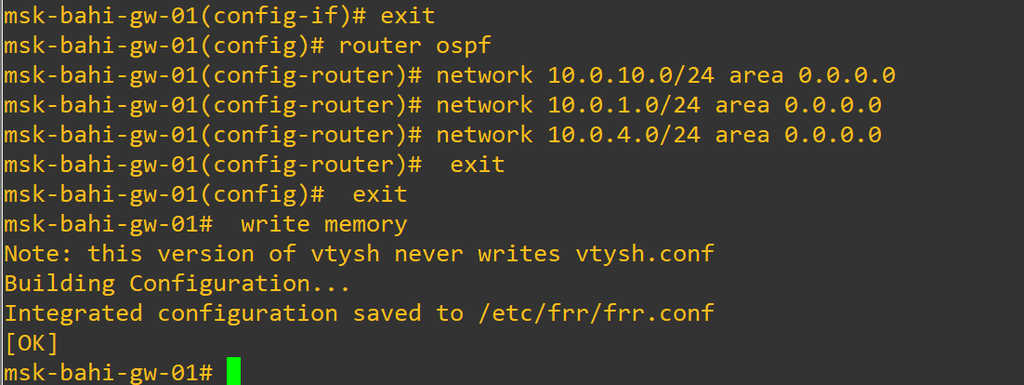

## Настройка OSPFv2 на msk-bahi-gw-02

- Включение процесса OSPFv2
- Объявление сетей:
  - 10.0.1.0/24
  - 10.0.2.0/24
- Добавление сетей в область 0.0.0.0
- Сохранение конфигурации FRR

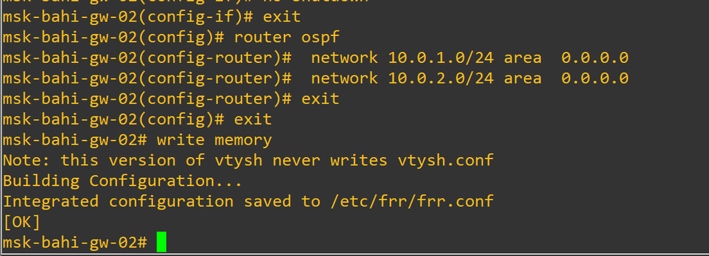

## Настройка OSPFv2 на msk-bahi-gw-03

- Активация OSPFv2
- Объявление сетей:
  - 10.0.11.0/24
  - 10.0.2.0/24
  - 10.0.3.0/24
- Использование области 0.0.0.0
- Сохранение конфигурации

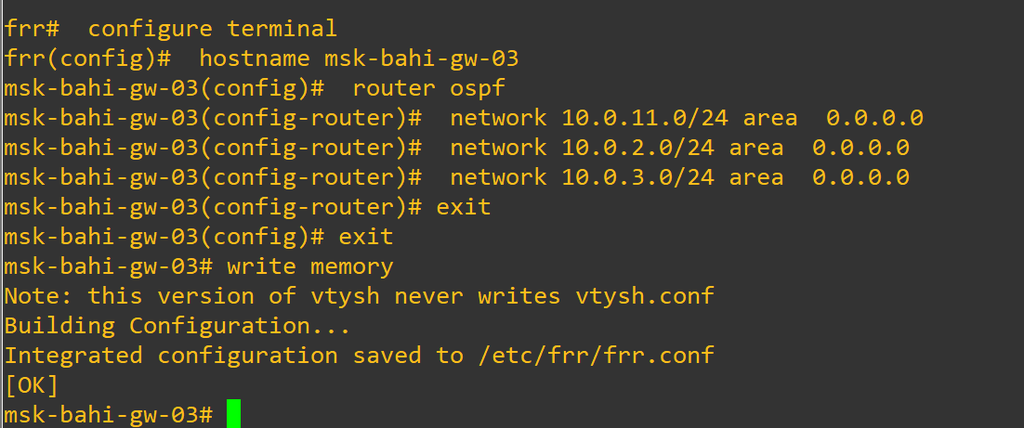

## Настройка OSPFv2 на msk-bahi-gw-04

- Включение OSPFv2
- Объявление сетей:
  - 10.0.3.0/24
  - 10.0.4.0/24
- Добавление в область 0.0.0.0
- Сохранение параметров маршрутизации

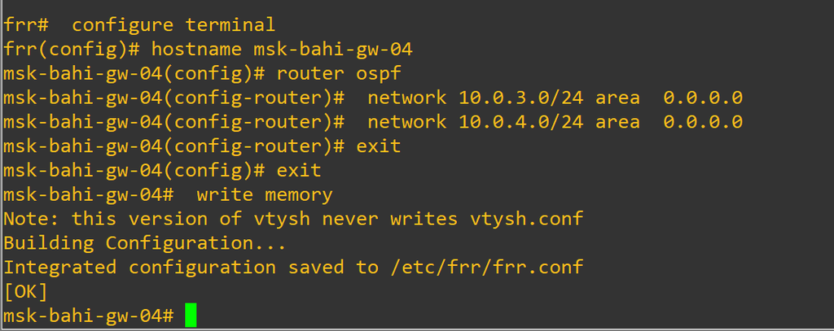

## Проверка связности PC1 → PC2 (IPv4, OSPFv2)

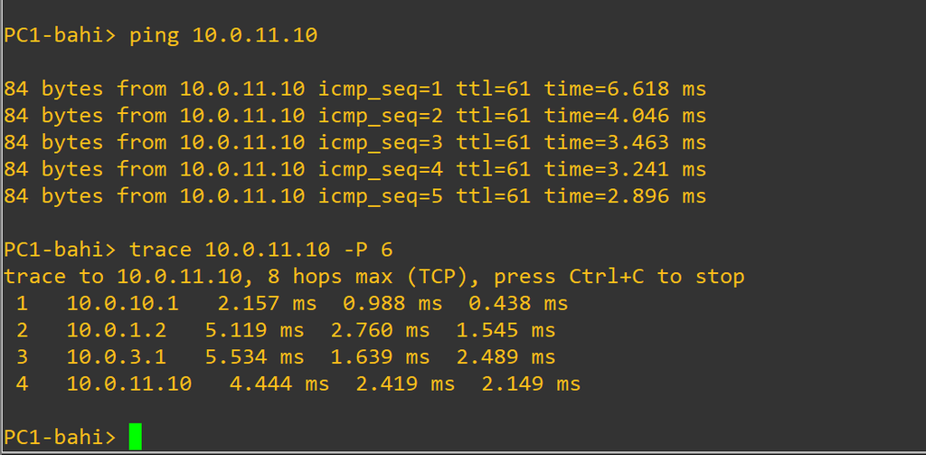

## Проверка соседства и маршрутов OSPFv2

- Команды проверки:
  - `show ip ospf neighbor`
  - `show ip ospf route`
- Соседи OSPF:
  - 10.0.1.2
  - 10.0.4.1
- Состояние: Full/Backup
- Два пути к сети 10.0.11.0/24

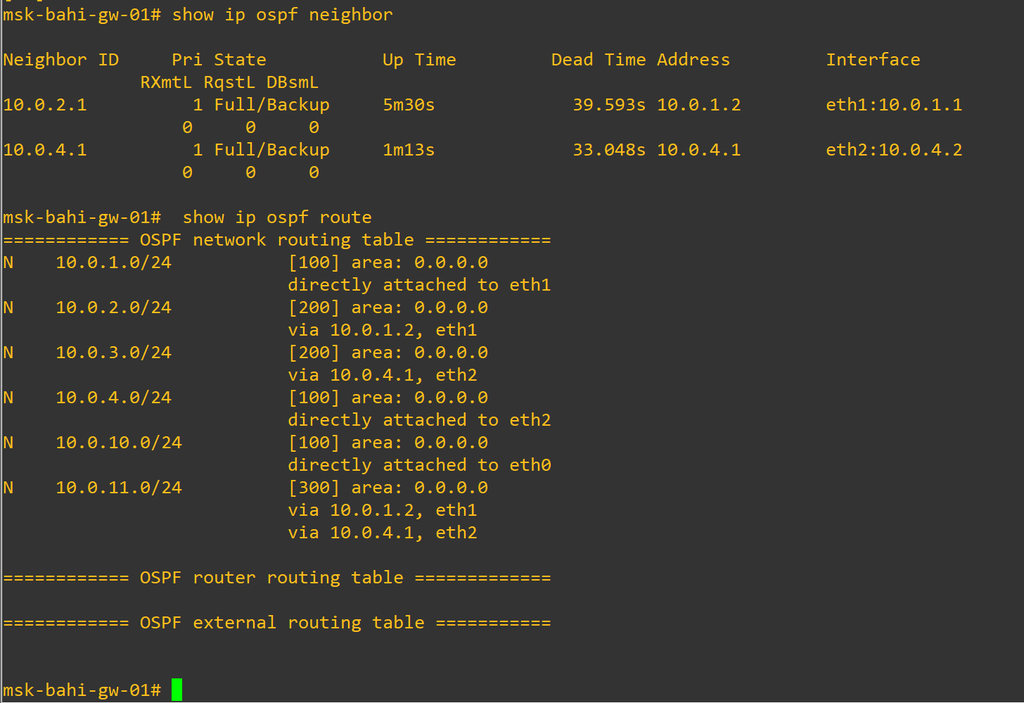

## Моделирование отказа канала (OSPFv2)

- Отключение интерфейса eth0
- Команда: `shutdown`
- Выполнено на msk-bahi-gw-02

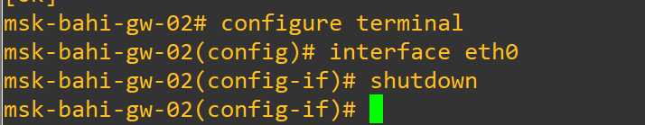